# Projekt zaliczeniowy

Wybrane pakiety do analizy danych 2024

Martyński Tomasz, 416797

03-01-2025

# Wybór i opis zbioru danych

Dostępnych jest 10 zbiorów danych. Do opracowania należy wybrać ten, którego numer jest równy **ostatniej cyfrze numeru indeksu**

Zbiór danych zawiera następujące informacje o studentach:

1. Numer_indeksu: unikalny numer indeksu studenta (liczba sześciocyfrowa).
2. Płeć: Płeć studenta, tj. “Kobieta” lub “Mężczyzna”.
3. Kierunek_studiów: kierunek, na którym studiuje student. Możliwe kierunki to: “Informatyka”, “Ekonomia”, “Psychologia”, “Biologia”.
4. Wiek: wiek studenta.
5. Czas_nauki: ilość godzin nauki tygodniowo.
6. Średnia_ocen: średnia ocen studenta.

# Przygotowanie danych

## Zadania

- Załaduj dane (kod, bez kreatora) i przekształć zmienne jakościowe na typ `factor`.
- Wyświetl podsumowanie danych. Na podstawie tego określ, które zmienne są jakościowe, a które ilościowe.

## Rozwiązania

```r
library(readxl)
data=read_excel("C:/Users/asus/Desktop/Programowanie/R/pRojekt/preferencje_studentow_z_srednia_ocen7.xlsx")

data$Numer_indeksu=as.factor(data$Numer_indeksu)
data$Płeć=as.factor(data$Płeć)
data$Kierunek_studiów=as.factor(data$Kierunek_studiów)
summary(data)
```

```
##  Numer_indeksu        Płeć        Kierunek_studiów      Wiek
##  700001 :  1   Kobieta  :157   Biologia   :118     Min.   :15.00
##  700002 :  1   Mężczyzna:331   Ekonomia   :128     1st Qu.:20.00
##  700003 :  1   NA's     : 12   Informatyka:117     Median :21.00
##  700004 :  1                   Psychologia:127     Mean   :20.96
##  700005 :  1                   NA's       : 10     3rd Qu.:22.00
##  700006 :  1                                       Max.   :27.00
##  (Other):494                                       NA's   :10
##    Czas_nauki      Średnia_ocen
##  Min.   : 0.050   Min.   :2.000
##  1st Qu.: 2.720   1st Qu.:3.190
##  Median : 4.455   Median :3.580
##  Mean   : 4.500   Mean   :3.643
##  3rd Qu.: 6.050   3rd Qu.:4.110
##  Max.   :12.710   Max.   :5.000
##  NA's   :8        NA's   :10
```

Zmienne jakościowe: Numer_indeksu, Płeć, Kierunek_studiów

Zmienne ilościowe: Wiek, Czas_nauki, Średnia_ocen

# Obsługa brakujących danych

## Zadania

Sprawdź, czy w zestawie danych występują wartości `NA`. Jeśli tak:

- Dla zmiennych jakościowych zastąp brakujące wartości najczęściej występującą kategorią.
- Dla zmiennych ilościowych zastąp brakujące wartości średnią. Pamiętaj, aby dla zmiennej “wiek” średnia była zaokrąglona do pełnych wartości.

## Rozwiązania

```r
colSums(is.na(data)) #w każdej kolumnie poza "Numer_indeksu" są wartości NA
```

```
##    Numer_indeksu             Płeć Kierunek_studiów             Wiek
##                0               12               10               10
##       Czas_nauki     Średnia_ocen
##                8               10
```

```r
library(Hmisc)
#zmienne jakościowe:
data$Płeć=impute(data$Płeć, fun=mean)
data$Kierunek_studiów=impute(data$Kierunek_studiów, fun=mean)

#zmienne ilościowe:
data$Wiek=round(impute(data$Wiek, fun=mean))
data$Czas_nauki=impute(data$Czas_nauki, fun=mean)
data$Średnia_ocen=impute(data$Średnia_ocen, fun=mean)


colSums(is.na(data)) #sprawdzam, czy nadal są wartości NA (nie ma :3)
```

```
##    Numer_indeksu             Płeć Kierunek_studiów             Wiek
##                0                0                0                0
##       Czas_nauki     Średnia_ocen
##                0                0
```

```r
summary(data)
```

```
##
##  12 values imputed to Mężczyzna
##
##
##  10 values imputed to Ekonomia
##
##
##  10 values imputed to 21
##
##
##  8 values imputed to 4.499573
##
##
##  10 values imputed to 3.643041
```

```
##  Numer_indeksu        Płeć        Kierunek_studiów      Wiek
##  700001 :  1   Kobieta  :157   Biologia   :118     Min.   :15.00
##  700002 :  1   Mężczyzna:343   Ekonomia   :138     1st Qu.:20.00
##  700003 :  1                   Informatyka:117     Median :21.00
##  700004 :  1                   Psychologia:127     Mean   :20.96
##  700005 :  1                                       3rd Qu.:22.00
##  700006 :  1                                       Max.   :27.00
##  (Other):494
##    Czas_nauki      Średnia_ocen
##  Min.   : 0.050   Min.   :2.000
##  1st Qu.: 2.748   1st Qu.:3.197
##  Median : 4.480   Median :3.590
##  Mean   : 4.500   Mean   :3.643
##  3rd Qu.: 6.040   3rd Qu.:4.100
##  Max.   :12.710   Max.   :5.000
##
```

# Funkcja wyznaczająca kwotę stypendium

## Zadania

Napisz funkcję, która na podstawie średniej określi, czy danej osobie należy się stypendium, a jeśli tak, to w jakiej wysokości.

Progi otrzymania stypendium:

- jeżeli średnia ≥ 4.5, to stypendium wynosi 750 zł,
- jeżeli średnia ≥ 4.7, to stypendium wynosi 850 zł,
- jeżeli średnia ≥ 4.9, to stypendium wynosi 950 zł.

Argumentem funkcji powinna być ramka danych.

Funkcja powinna zwrócić listę (lista - jako obiekt w R) złożoną z 3 elementów:

- liczby przyznanych stypendiów,
- macierzy/ramki danych z numerami indeksów stypendystów wraz z wyliczonymi kwotami,
- miesięcznego kosztu stypendium (sumy wszystkich przyznanych stypendiów).

## Rozwiązania

```r
kwota_styp=function(srednia){
  return (750*(srednia>=4.5)+100*(srednia>=4.7)+100*(srednia>=4.9))
}

stypendia=function(frame){
wart=kwota_styp(frame$Średnia_ocen) #wartosc, jaka dostanie kazdy student
indeksy_stypendystów=which(wart!=0) #indeksy stypendystow (stypednium >0)

kto=frame$Numer_indeksu[indeksy_stypendystów] #nr-y indeksu stypendystow
ile=wart[wart!=0] #wysokosc kwot pryznanej stypendystom
df=data.frame(NrIndeksu=kto, WartoscPLN=ile)

final_l=list(
  liczba_stypendystow=sum(wart!=0),
  ramka=df,
  laczna_wartosc_stypendiów=sum(wart)
)
  return (final_l)
}

stypendia(data)
```

```
## $liczba_stypendystow
## [1] 49
##
## $ramka
##     NrIndeksu WartoscPLN
## 3      700003        850
## 7      700007        850
## 41     700041        850
## 51     700051        950
## 53     700053        750
## 54     700054        750
## 68     700068        850
## 74     700074        950
## 95     700095        850
## 103    700103        850
```

[output cut: 42 more lines]

# Wykres słupkowy dla kierunku studiów i płci

## Zadania

- Używając biblioteki ggplot, stwórz wykres słupkowy (pionowe słupki) porównujący kierunek studiów z płcią. Wykres powinien mieć odpowiednio podpisane osie, tytuł, legendę oraz zmienione kolory słupków i tła.
- Na podstawie otrzymanego wykresu, opisz, jakie wnioski można wyciągnąć na temat zależności między płcią a kierunkiem studiów w zbiorze danych.

## Rozwiązania

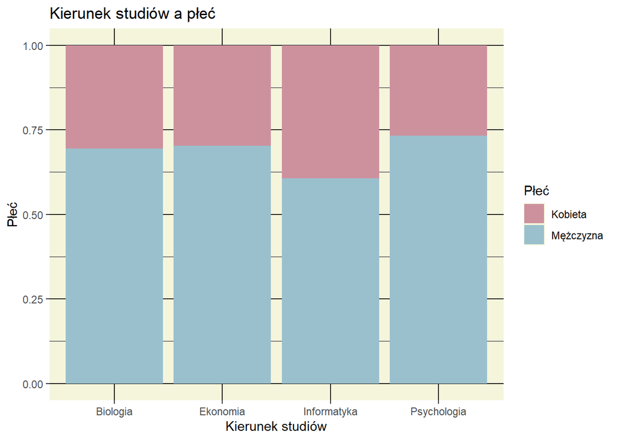

```r
library(ggplot2)

ggplot(data, aes(x=Kierunek_studiów, fill=Płeć))+
  geom_bar(position="fill")+
  labs(title="Kierunek studiów a płeć", x="Kierunek studiów", y="Płeć")+
  scale_fill_manual(values=c("pink3", "lightblue3"))+
  theme(
    panel.background = element_rect(fill="beige"),
    panel.grid.major = element_line(color="gray8"),
    panel.grid.minor = element_line(color="gray8")
  )
```

Wnioski: w naszej próbce danych wszystkie kierunki są lekko zdominowane przez mężczyzn, ale - co ciekawe - największy odsetek kobiet występuje na Informatyce, a najmniejszy - na Psychologii.

Brakuje mocnej zależności między płcią a kierunkiem typu “jak mężczyzna, to pewnie na Biologii” - wszystkie kierunki mają między około 60% a 75% mężczyzn, brak kierunku skrajnie inaczej podzielonego pod tym względem. Warto dodać, że na wszystkich kierunkach mamy podobną liczbę ludzi, tzn. między 117 a 138, a więc i pod tym względem kierunki są porównywalne.

# Histogram dla średniej ocen

## Zadania

- Stwórz histogram dla średniej ocen, dodając linię reprezentującą jądrowy estymator gęstości oraz przerywane linie oznaczające średnią, modę i medianę. Oznacz osie, nadaj tytuł, zmień kolory histogramu oraz linii i dodaj legendę (legendy powinny uwzględniać styl linii, np. przerywana linia w legendzie odpowiada przerywanej linii na wykresie).
- Określ charakterystykę rozkładu: modalność, skośność i symetryczność.

## Rozwiązania

```
## Defaulting to continuous.
```

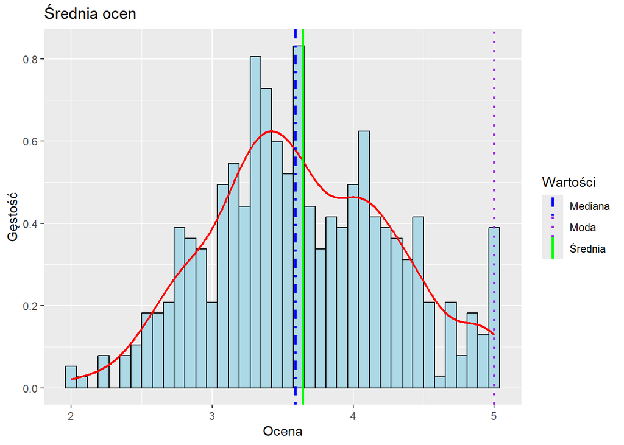

```r
moda=function(dane){
  wystapienia=table(dane)
  mod=as.numeric(names(wystapienia)[which.max(wystapienia)])
  return (mod)
}


ggplot(data, aes(x=Średnia_ocen, y=..density..)) +
  geom_histogram(bins=40, fill="lightblue", color ="black") +
  geom_density(color = "red", size=0.75)+
  geom_vline(aes(xintercept=mean(Średnia_ocen), color="Średnia"), linetype="solid", size=1)+
  geom_vline(aes(xintercept=median(Średnia_ocen), color="Mediana"), linetype="dotdash", size=1)+
  geom_vline(aes(xintercept=moda(Średnia_ocen), color="Moda"), linetype="dotted", size=1)+
  labs(title="Średnia ocen", x="Ocena", y ="Gęstość")+
  scale_color_manual(name="Wartości", values=c("Średnia" = "green", "Mediana" = "blue", "Moda"="purple"))
```

```r
library(moments)
skewness(data$Średnia_ocen)
```

```
## [1] 0.1248098
```

```r
median(data$Średnia_ocen)
```

```
## [1] 3.59
```

```r
kurtosis(data$Średnia_ocen)
```

```
## [1] 2.522572
```

Charakterystyka rozkładu:

- modalność: rozkład jest unimodalny (nie wiem, jak interpretować to, że koncentruje się on wokół 3,59, natomiast jego moda jest równa 5 - normalnie bym powiedział, że jest unimodalny, ale czy moda w 5 sprawia, że jest bimodalny?)
- skośność - bliska 0, symetryczny rozkład
- kurtoza - około 2,5, a więc trochę mniejsza niż rozkładu normalnego, ale nadal oznaczająca koncentrację gęstości w środku i lżejsze ogony (poza tą feralną modą równą 5…)

# Wykresy pudełkowe dla czasu nauki a kierunek studiów

## Zadania

- Przy użyciu ggplot, narysuj wykresy pudełkowe dla czasu nauki w podziale na kierunek studiów. Wykres powinien mieć podpisane osie, tytuł oraz zmienione kolory.
- Na podstawie wykresu określ, czy rozkłady czasu nauki różnią się w zależności od kierunku. Który kierunek wymaga średnio najwięcej czasu, a który najmniej? Który kierunek charakteryzuje się największą wariancją? Czy są widoczne wartości odstające i jak je zidentyfikować?

## Rozwiązania

```
## Defaulting to continuous.
```

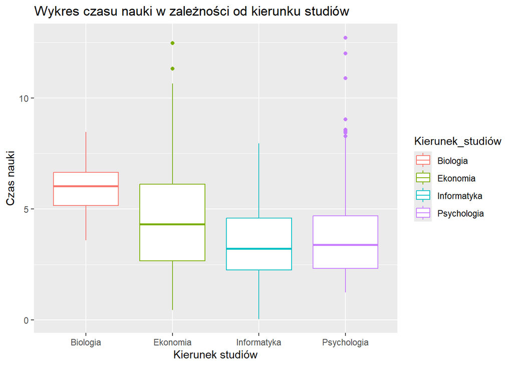

```r
ggplot(data, aes(x=Kierunek_studiów, y=Czas_nauki, color=Kierunek_studiów))+
  geom_boxplot()+
  labs(x="Kierunek studiów", y="Czas nauki", title="Wykres czasu nauki w zależności od kierunku studiów")
```

Tak, rozkład czasu różni się w zależności od kierunku - średnio najdłużej uczą się studenci Biologii, a najkrócej studenci Informatyki. Ekonomia charakteryzuje się największą wariancją (to sugeruje największa szerokość pudełka, który sięga od 1. do 3. kwartylu). Wartości odstające obswerujemy dla Ekonomii i Psychologii - są to kropki nad wąsami wykresu.

# Analiza rozkładu czasu nauki dla najliczniejszego kierunku studiów

## Zadania

- Wybierz czas nauki dla najliczniejszego kierunku studiów. Przeprowadź analizę rozkładu: przetestuj i porównaj dwa lub trzy różne rozkłady, wyestymuj ich parametry i oceń dopasowanie.

Rodziny rozkładów: wykładniczy `exp`, logarytmiczno-normalny `lnorm`, gamma `gamma`, normalny `norm`, t-Studenta `t`, Weibulla `weibull`, beta `beta`, jednostajny `unif`

## Rozwiązania

```r
summary(data$Kierunek_studiów) #widzimy, że najwięcej jest studentów ekonomii, nawet bez tych 10, których przypisaliśmy w ramach uzupełniania NA
```

```
##
##  10 values imputed to Ekonomia
```

```
##    Biologia    Ekonomia Informatyka Psychologia
##         118         138         117         127
```

```r
dane=c(data[which(data$Kierunek_studiów=="Ekonomia"),]$Czas_nauki)

library(fitdistrplus)
```

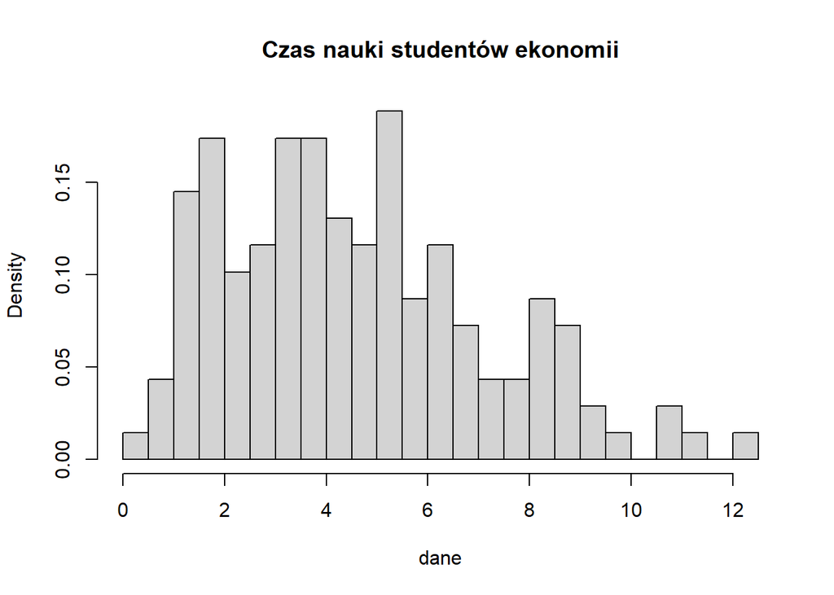

```r
hist(dane, breaks=30, main="Czas nauki studentów ekonomii", probability = TRUE)
```

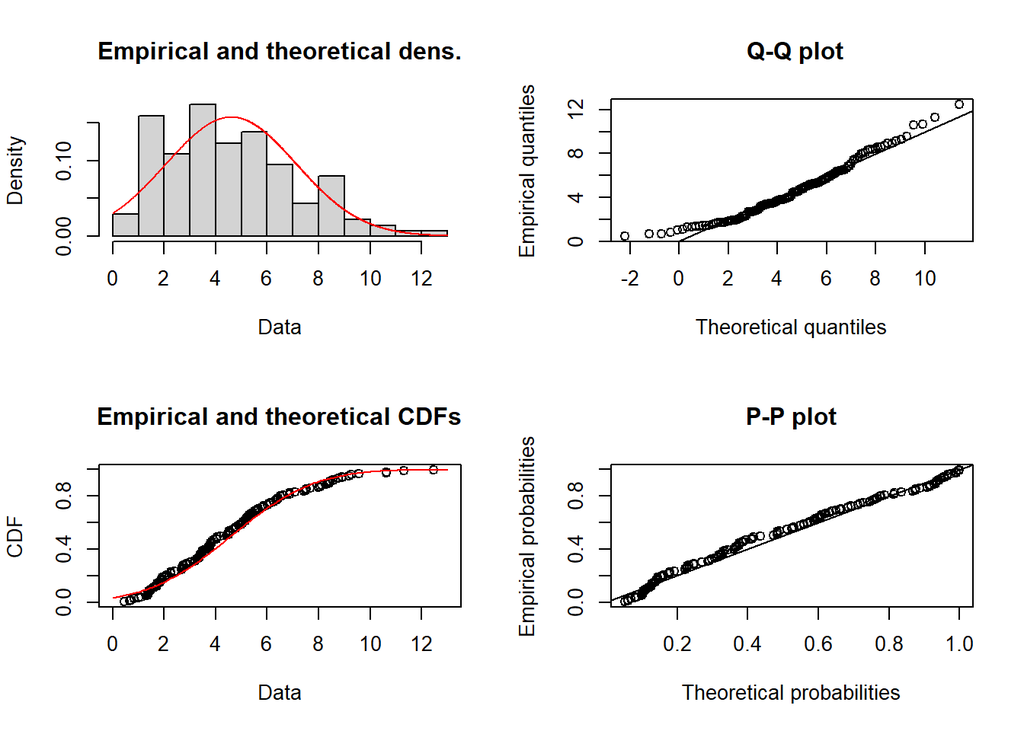

```r
#rozkład normalny
fit_norm=fitdist(dane, "norm")
plot(fit_norm)
```

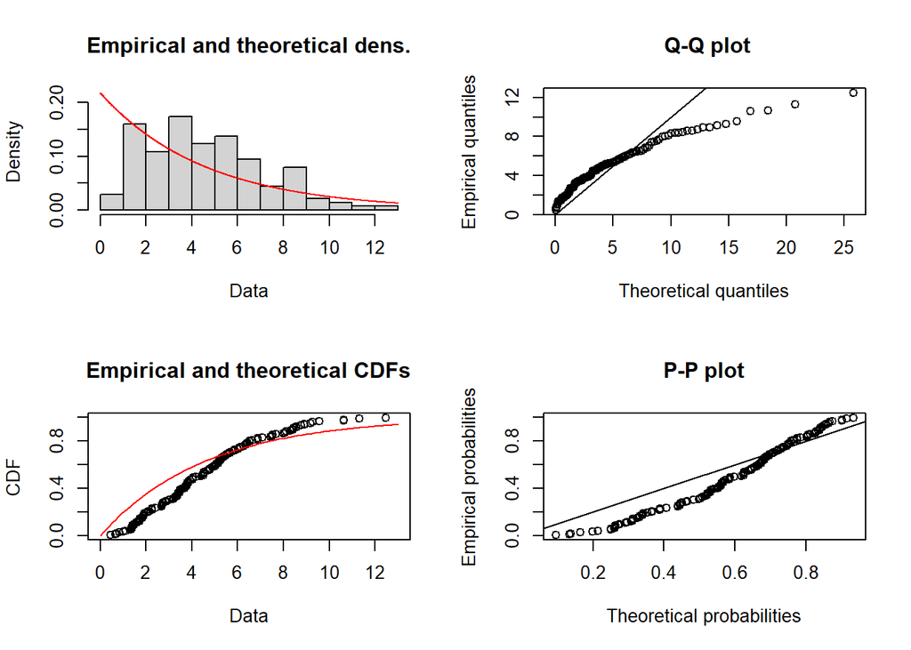

```r
#rozkład wykładniczy
fit_exp=fitdist(dane, "exp")
plot(fit_exp)
```

```r
print(fit_exp)
```

```
## Fitting of the distribution ' exp ' by maximum likelihood
## Parameters:
##       estimate Std. Error
## rate 0.2174775 0.01851253
```

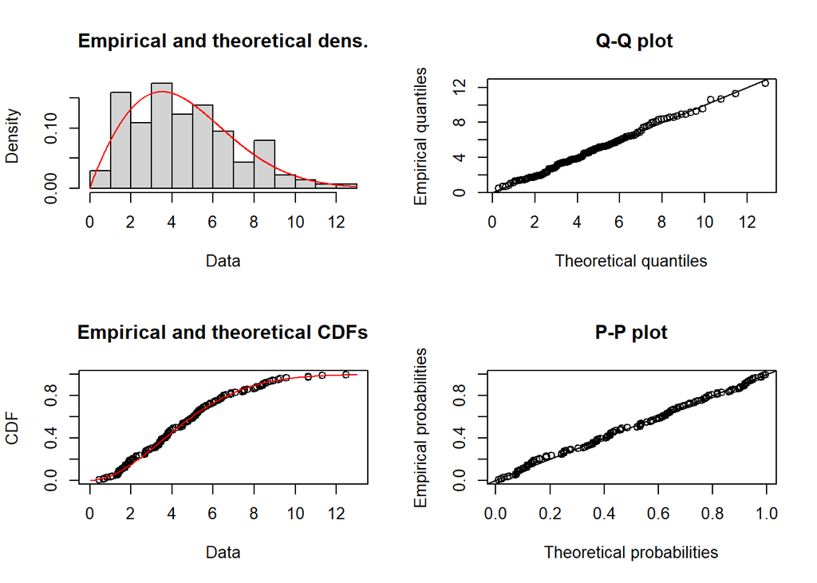

```r
#rokzład Weibulla
fit_weibull=fitdist(dane, "weibull")
plot(fit_weibull)
```

```r
print(fit_weibull)
```

```
## Fitting of the distribution ' weibull ' by maximum likelihood
## Parameters:
##       estimate Std. Error
## shape 1.901112  0.1267645
## scale 5.191254  0.2450618
```

```r
results=gofstat(list(fit_norm, fit_exp, fit_weibull), fitnames = c("Normalny", "Wykładniczy", "Weibulla"))
print(results)
```

```
## Goodness-of-fit statistics
##                                Normalny Wykładniczy   Weibulla
## Kolmogorov-Smirnov statistic 0.07825642   0.2076931 0.04831393
## Cramer-von Mises statistic   0.18751159   2.1007755 0.03757512
## Anderson-Darling statistic   1.34201280  11.5687954 0.29267279
##
## Goodness-of-fit criteria
##                                Normalny Wykładniczy Weibulla
## Akaike's Information Criterion 652.5095    699.0821 632.2946
## Bayesian Information Criterion 658.3640    702.0093 638.1491
```

Spośród sprawdzonych przeze mnie rozkładów (normalny, wykładniczy, Weibulla) najlepiej dopasowany jest ten ostatni, na co wskazują najmniejsze wartości statystyk oraz AIC i BIC. Rozkład normalny przybliża nasze dane lepiej niż rozkład wykładniczy.

Estymacja parametrów:

```r
print(fit_weibull)
```

```
## Fitting of the distribution ' weibull ' by maximum likelihood
## Parameters:
##       estimate Std. Error
## shape 1.901112  0.1267645
## scale 5.191254  0.2450618
```

```r
print(fit_exp)
```

```
## Fitting of the distribution ' exp ' by maximum likelihood
## Parameters:
##       estimate Std. Error
## rate 0.2174775 0.01851253
```

```r
print(fit_norm)
```

```
## Fitting of the distribution ' norm ' by maximum likelihood
## Parameters:
##      estimate Std. Error
## mean 4.598176  0.2159101
## sd   2.536369  0.1526714
```

- Weibull: k=1,901112, lambda=5,191254 <- nasz najbardziej pasujący rozkład
- wykładniczy: lambda=0.2174775
- normalny: m=4,598176, sigma=2,536369

# Wykres zależności średniej ocen od czasu nauki dla kierunku “Biologia”.

## Zadania

- Stwórz wykres punktowy, przedstawiający zależność średniej ocen od czasu nauki dla kierunku “Biologia”. Wykres powinien mieć podpisane osie, tytuł, zmienione kolory oraz legendę.
- Na podstawie wykresu określ, jaki rodzaj zależności występuje między zmiennymi. Oblicz korelację między średnią ocen a czasem nauki. Sprawdź założenia regresji liniowej, wyestymuj współczynniki prostej regresji i dodaj ją na wykres. Przeprowadź również diagnostykę modelu za pomocą odpowiednich wykresów.

## Rozwiązania

```
## Defaulting to continuous.
```

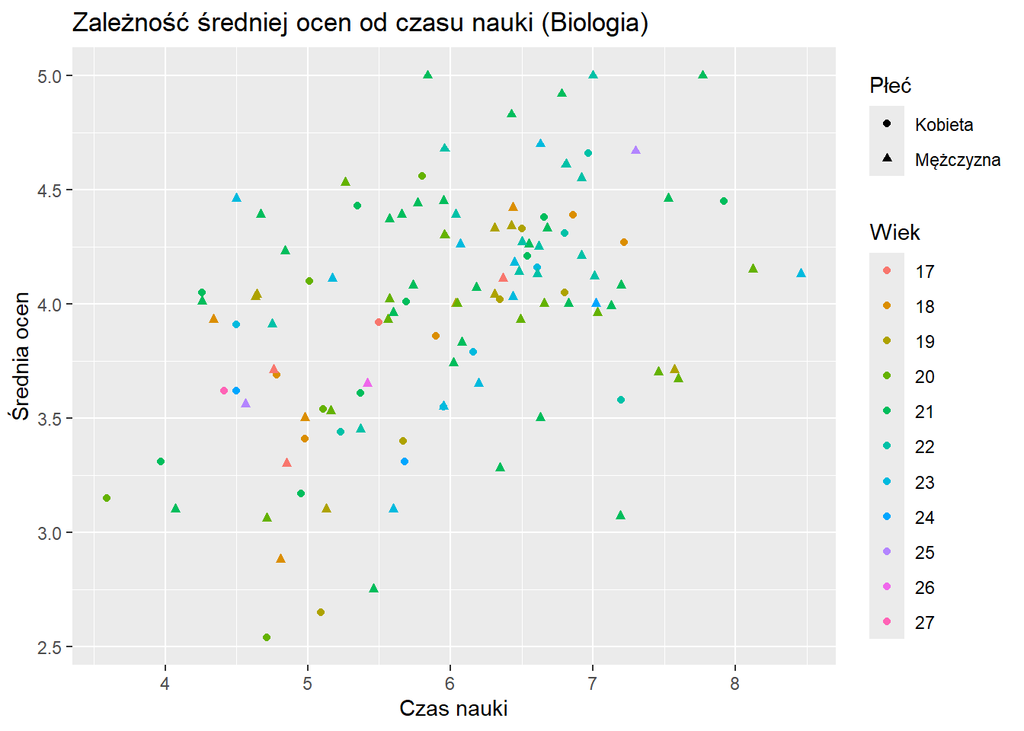

```r
dane_b=data[which(data$Kierunek_studiów=="Biologia"),]
dane_b$Wiek=as.factor(dane_b$Wiek)

rys=ggplot(dane_b, aes(x=Czas_nauki, y=Średnia_ocen, color=Wiek, shape=Płeć))+
  geom_point()+
  labs(x="Czas nauki", y="Średnia ocen", color="Wiek", shape="Płeć", title="Zależność średniej ocen od czasu nauki (Biologia)")
rys
```

```r
#korelacja
cor(dane_b$Średnia_ocen, dane_b$Czas_nauki)
```

```
## [1] 0.443058
```

```r
model=lm(Średnia_ocen~Czas_nauki, data=dane_b)
```

Sprawdzamy, czy nasz model spełnia założenia regresji liniowej:

- niewielka p-value - rzędu 10^(-7) - a więc zależność jest liniowa:

  ```r
  summary(model)
  ```

  ```
  ##
  ## Call:
  ## lm(formula = Średnia_ocen ~ Czas_nauki, data = dane_b)
  ##
  ## Residuals:
  ##     Min      1Q  Median      3Q     Max
  ## -1.1711 -0.2459  0.0258  0.3258  1.0613
  ##
  ## Coefficients:
  ##             Estimate Std. Error t value Pr(>|t|)
  ## (Intercept)  2.63074    0.25427  10.346  < 2e-16 ***
  ## Czas_nauki   0.22397    0.04208   5.323 5.06e-07 ***
  ## ---
  ## Signif. codes:  0 '***' 0.001 '**' 0.01 '*' 0.05 '.' 0.1 ' ' 1
  ##
  ## Residual standard error: 0.4544 on 116 degrees of freedom
  ## Multiple R-squared:  0.1963, Adjusted R-squared:  0.1894
  ## F-statistic: 28.33 on 1 and 116 DF,  p-value: 5.056e-07
  ```

- niezależność obserwacji - jedna obserwacja jest oczywiście niezależna, bo nie jest jednostajna
- testowanie homoskedantyczności - test Breusch-Pagana: p-value jest wielkości prawie 40%, dużo większa niż 0.05, a więc nie odrzucamy hipotezy zerowej - wariacja jest jednorodna

  ```r
  library(lmtest)
  bptest(model)
  ```

  ```
  ##
  ##  studentized Breusch-Pagan test
  ##
  ## data:  model
  ## BP = 0.71057, df = 1, p-value = 0.3993
  ```

- niezależność reszt - bardzo wysoka p-value, dużo większa niż 0.05, a więc reszty są niezależne

  ```r
  library("car")
  durbinWatsonTest(model)
  ```

  ```
  ##  lag Autocorrelation D-W Statistic p-value
  ##    1      -0.0110908       2.01998   0.908
  ##  Alternative hypothesis: rho != 0
  ```

- rozkład normalny reszt - test Shapiro-Wilka - p-value jest zdecydowanie większa niż 0.05, a więc reszty mają rozkład normalny

  ```r
  shapiro.test(model$residuals)
  ```

  ```
  ##
  ##  Shapiro-Wilk normality test
  ##
  ## data:  model$residuals
  ## W = 0.98651, p-value = 0.2903
  ```

  Wniosek - model spełnia założenia modelu liniowego.

```r
model$coeff
```

```
## (Intercept)  Czas_nauki
##   2.6307425   0.2239684
```

```
## Defaulting to continuous.
```

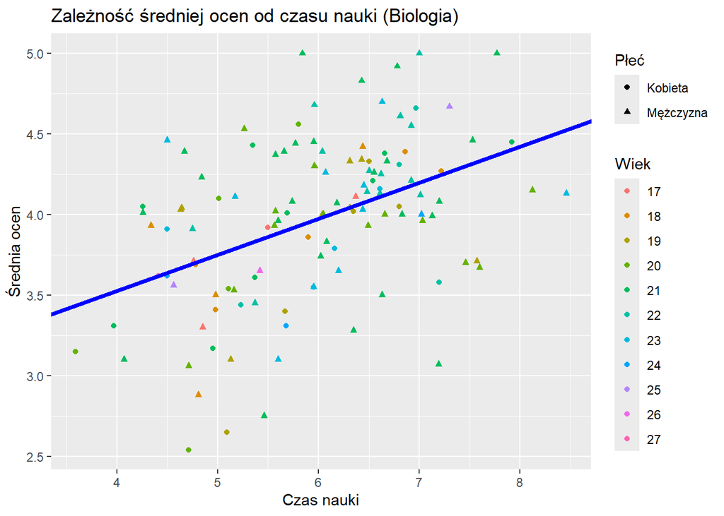

```r
rys=rys+geom_abline(intercept=2.6307425, slope=0.2239684, col="blue", size=1.5)
rys
```

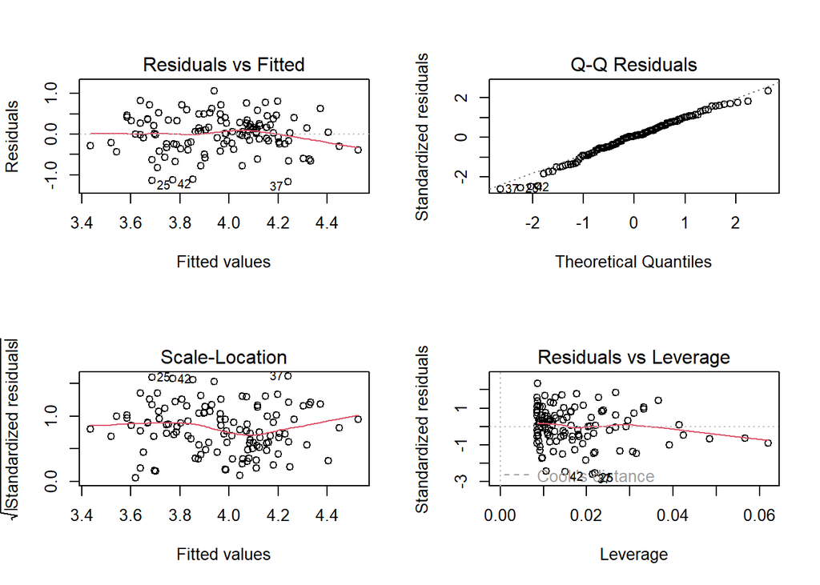

```r
par(mfrow=c(2,2))
plot(model)
```

Rodzaj zależności między zmiennymi - średnio większy czas nauki przynosi średnio lepszą średnią ocen (dodatni współczynnik “slope”).

Na podstawie wykresów możemy stwierdzić, że model spełnia założenia modelu liniowego:

- na wykresie Residuals vs Fitted czerwona krzywa jest bliska 0
- na wykresie Q-Q Residuals dane układają się wzdłuż prostej bliskiej y=x
- na wykresie Scale-Location widać równomierne rozmieszczenie punktów względem czerwonej krzywej
- na wykresie Residuals vs Leverage widać, że zdecydowana większość obserwacji znajduje się po lewej stronie, a więc nieliczne z nich wpływają znacząco na zaburzenie wyniku

  Model **nie** jest dobry, choć spełnia założenia i przeszedł pomyślnie diagniostykę, gdyż mamy bardzo mały współczynnik R^2 (odpowiedzialny za dopasowanie modelu).